# Answers of the test file, sheet 1

Importing necessary libraries for analysis

```python
import pandas as pd
import numpy as np
import matplotlib.pyplot as plt
import seaborn as sns
```

Reading the test file

```python
df=pd.read_excel(r'C:\Users\Carnival\Downloads\Data_Specialist_Test (9).xlsx', header=11)
```

Exploring the file's information

```python
df.info()
```

```
<class 'pandas.core.frame.DataFrame'>
RangeIndex: 26 entries, 0 to 25
Data columns (total 9 columns):
 #   Column          Non-Null Count  Dtype
---  ------          --------------  -----
 0   Unnamed: 0      0 non-null      float64
 1   Campaign        26 non-null     object
 2   Clicks          26 non-null     int64
 3   Impressions     26 non-null     int64
 4   Installs        26 non-null     int64
 5   Cost / Install  26 non-null     float64
 6   Cost            26 non-null     float64
 7   IR              26 non-null     float64
 8   CTR             26 non-null     float64
dtypes: float64(5), int64(3), object(1)
memory usage: 2.0+ KB
```

Printing the first five rows

```python
df.head()
```

|  | Unnamed: 0 | Campaign | Clicks | Impressions | Installs | Cost / Install | Cost | IR | CTR |
| --- | --- | --- | --- | --- | --- | --- | --- | --- | --- |
| 0 | NaN | C1 | 3843 | 64572 | 2739 | 0.07 | 178.49 | 0.7127 | 0.0595 |
| 1 | NaN | C13 | 1315 | 13951 | 686 | 0.01 | 5.66 | 0.5213 | 0.0943 |
| 2 | NaN | C16 | 5016 | 42564 | 2438 | 0.06 | 140.05 | 0.4860 | 0.1178 |
| 3 | NaN | C18 | 1245 | 15196 | 601 | 0.05 | 31.18 | 0.4827 | 0.0819 |
| 4 | NaN | C19 | 19983 | 334125 | 9481 | 0.09 | 900.27 | 0.4745 | 0.0598 |

Deletion of the first column

```python
del df["Unnamed: 0"]
```

Checking the data after deletion

```python
df.head(30)
```

|  | Campaign | Clicks | Impressions | Installs | Cost / Install | Cost | IR | CTR |
| --- | --- | --- | --- | --- | --- | --- | --- | --- |
| 0 | C1 | 3843 | 64572 | 2739 | 0.07 | 178.49 | 0.7127 | 0.0595 |
| 1 | C13 | 1315 | 13951 | 686 | 0.01 | 5.66 | 0.5213 | 0.0943 |
| 2 | C16 | 5016 | 42564 | 2438 | 0.06 | 140.05 | 0.4860 | 0.1178 |
| 3 | C18 | 1245 | 15196 | 601 | 0.05 | 31.18 | 0.4827 | 0.0819 |
| 4 | C19 | 19983 | 334125 | 9481 | 0.09 | 900.27 | 0.4745 | 0.0598 |
| 5 | C20 | 3524 | 49539 | 1670 | 0.06 | 106.68 | 0.4739 | 0.0711 |
| 6 | C22 | 7661 | 88226 | 3611 | 0.05 | 193.42 | 0.4713 | 0.0868 |
| 7 | C23 | 6491 | 41714 | 3042 | 0.04 | 134.71 | 0.4686 | 0.1556 |
| 8 | C24 | 13737 | 188781 | 6357 | 0.06 | 395.92 | 0.4628 | 0.0728 |
| 9 | C26 | 2342 | 27521 | 1072 | 0.06 | 60.65 | 0.4577 | 0.0851 |
| 10 | C28 | 9218 | 120445 | 4177 | 0.07 | 301.69 | 0.4531 | 0.0765 |
| 11 | C29 | 28374 | 383130 | 12854 | 0.07 | 894.61 | 0.4530 | 0.0741 |
| 12 | C3 | 8779 | 113469 | 5530 | 0.06 | 341.81 | 0.6299 | 0.0774 |
| 13 | C30 | 29828 | 290666 | 13395 | 0.06 | 852.62 | 0.4491 | 0.1026 |
| 14 | C32 | 3949 | 88530 | 1721 | 0.10 | 173.41 | 0.4358 | 0.0446 |
| 15 | C34 | 24984 | 601658 | 10557 | 0.11 | 1146.60 | 0.4226 | 0.0415 |
| 16 | C36 | 32132 | 383462 | 13450 | 0.06 | 873.03 | 0.4186 | 0.0838 |
| 17 | C37 | 3189 | 210200 | 1325 | 0.17 | 224.69 | 0.4155 | 0.0152 |
| 18 | C40 | 18921 | 470547 | 7445 | 0.12 | 905.37 | 0.3919 | 0.0402 |
| 19 | C41 | 27469 | 614535 | 10650 | 0.10 | 1026.33 | 0.3877 | 0.0447 |
| 20 | C43 | 6000 | 205395 | 2103 | 0.11 | 236.85 | 0.3473 | 0.0292 |
| 21 | C44 | 5395 | 196479 | 1733 | 0.14 | 250.21 | 0.3187 | 0.0275 |
| 22 | C47 | 21943 | 1145112 | 5486 | 0.18 | 987.36 | 0.2500 | 0.0192 |
| 23 | C48 | 2265 | 87696 | 898 | 0.26 | 229.69 | 0.0449 | 0.0258 |
| 24 | C7 | 2625 | 25439 | 1572 | 0.04 | 56.31 | 0.5989 | 0.1032 |
| 25 | C9 | 27631 | 372263 | 15789 | 0.07 | 1030.25 | 0.5714 | 0.0742 |

Checking if there are duplicate data

```python
df.duplicated()
```

```
0     False
1     False
2     False
3     False
4     False
5     False
6     False
7     False
8     False
9     False
10    False
11    False
12    False
13    False
14    False
15    False
16    False
17    False
18    False
19    False
20    False
21    False
22    False
23    False
24    False
25    False
dtype: bool
```

Key figures to explore and analyse the data

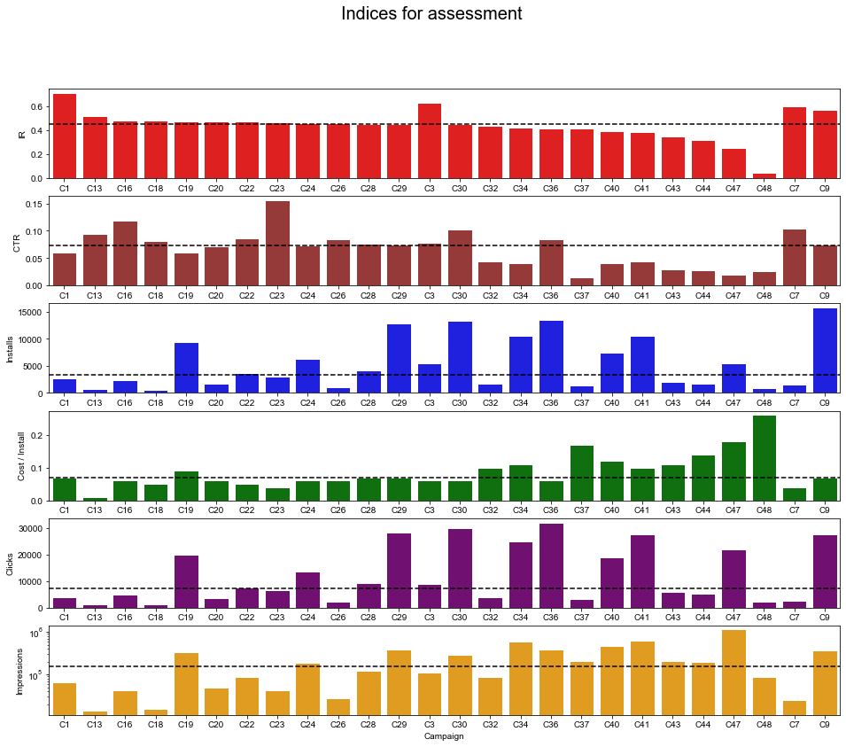

```python
fig, axes = plt.subplots(6,1, figsize=(16, 13))
fig.suptitle('Indices for assessment', fontsize=20)
sns.set_theme(style="darkgrid")

sns.barplot(ax=axes[0],x='Campaign', y="IR", data=df, color='red')
axes[0].axhline(np.median(df['IR']), ls='--', color='black')

sns.barplot(ax=axes[1],x='Campaign', y="CTR ", data=df, color='brown')
axes[1].axhline(np.median(df['CTR ']), ls='--', color='black')

sns.barplot(ax=axes[2],x='Campaign', y="Installs", data=df, color='blue')
axes[2].axhline(np.median(df['Installs']), ls='--', color='black')


sns.barplot(ax=axes[3],x='Campaign', y="Cost / Install", data=df, color='green')
axes[3].axhline(np.median(df["Cost / Install"]), ls='--', color='black')


sns.barplot(ax=axes[4],x='Campaign', y="Clicks", data=df, color='purple')
axes[4].axhline(np.median(df["Clicks"]), ls='--', color='black')


sns.barplot(ax=axes[5],x='Campaign', y="Impressions", data=df, color='orange')
axes[5].axhline(np.median(df["Impressions"]), ls='--', color='black')
axes[5].set_yscale("log")
```

**1.b) How would you suggest to optimise these campaigns or what changes would you recommend? Which campaign would you allocate more resources to?**

> *To optimise these campaigns, the number of clicks and impressions have to increase by enhancing the quality of the advertisement. Basically, most of the campaigns has high IR. Thus, if the clicks are getting better, the installation will increase.*

**1.c) What other conclusion can you make from the data?**

> *Almost half of the campaigns got got impressions lower the median value which is the center point of al values.*

**2. Make a simple graph and indicate in title what you want to highlight?**

> *The figure below*

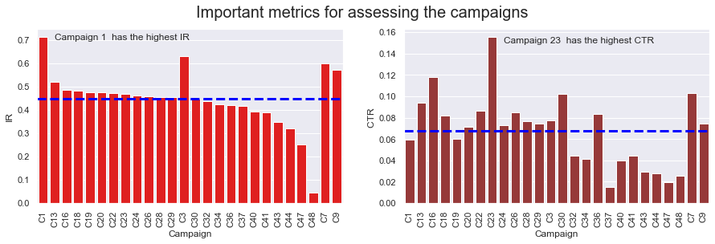

```python
fig, ax = plt.subplots(1,2,figsize=(15,4))
fig.suptitle('Important metrics for assessing the campaigns', fontsize=20)
sns.set_theme()

sns.barplot(ax=ax[0],x='Campaign', y="IR", data=df, color='red');
ax[0].axhline(np.mean(df['IR']), ls='--', lw=3, color='blue');
ax[0].tick_params(axis='x', rotation=90)
ax[0].text(1,0.7,"Campaign 1  has the highest IR")

sns.barplot(ax=ax[1],x='Campaign', y="CTR ", data=df, color='brown');
ax[1].axhline(np.mean(df['CTR ']), ls='--', lw=3, color='blue');
ax[1].tick_params(axis='x', rotation=90)
ax[1].text(8,0.15,"Campaign 23  has the highest CTR");
```

**3. What question would you ask your manager about this data set or this task?**

> *I would ask the manager about the platofrms he used for the advertisement campaigns, the sales revenue for each campaign and the data resources; are the data sources trustworthy? and whose perspective am I considering?*